# Reproducible Research: Peer Assessment 1

## Assignment Instructions

1. Code for reading in the dataset and/or processing the data
2. Histogram of the total number of steps taken each day
3. Mean and median number of steps taken each day
4. Time series plot of the average number of steps taken
5. The 5-minute interval that, on average, contains the maximum number of steps
6. Code to describe and show a strategy for imputing missing data
7. Histogram of the total number of steps taken each day after missing values are imputed
8. Panel plot comparing the average number of steps taken per 5-minute interval across weekdays and weekends
9. All of the R code needed to reproduce the results (numbers, plots, etc.) in the report

## 1. Loading and preprocessing the data

First we have to unzip the data and read it into R

```r
unzip("activity.zip")
rawdata<-read.csv("activity.csv")
library(ggplot2)
head(rawdata)
```

```
##   steps       date interval
## 1    NA 2012-10-01        0
## 2    NA 2012-10-01        5
## 3    NA 2012-10-01       10
## 4    NA 2012-10-01       15
## 5    NA 2012-10-01       20
## 6    NA 2012-10-01       25
```

## 2. Histogram of the total steps per day

Now a histogram of the frequency of total steps per day is shown.

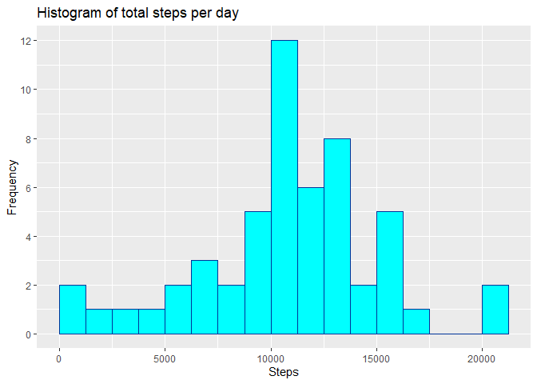

```r
spd<- aggregate(steps ~ date, rawdata, sum)
g<-ggplot(spd, aes(steps))
g+geom_histogram(boundary=0, binwidth=1250,color="#003399", fill="#00FFFF")+
                xlab("Steps")+ ylab("Frequency") +
                ggtitle("Histogram of total steps per day")+
                scale_y_continuous(breaks=seq(0,14,2))
```

## 3. Mean and median number of steps taken each day

The mean and the median of the total amount of steps is calculated.

```r
meanpd<-mean(spd$steps, na.rm = TRUE)
medianpd<-median(spd$steps, na.rm = TRUE)
```

```r
meanpd
```

```
## [1] 10766.19
```

```r
medianpd
```

```
## [1] 10765
```

## 4. Time series plot of the average number of steps taken

The average number of steps for every 5 minutes interval is shown in the following figure.

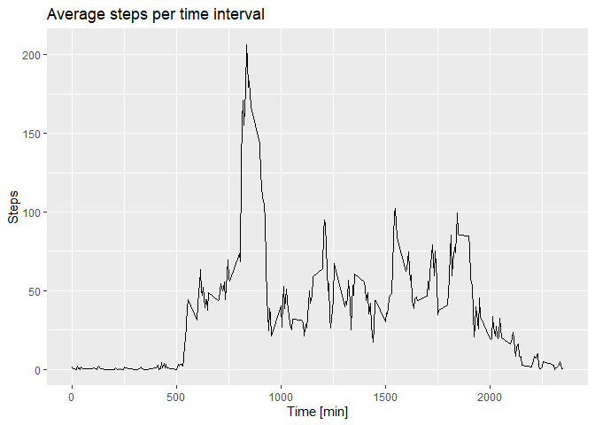

```r
sti<- aggregate(steps ~ interval, rawdata, mean, na.action = na.omit)
h<-ggplot(sti, aes(interval, steps))
h+geom_line() + ggtitle("Average steps per time interval")+
    xlab("Time [min]") + ylab("Steps")
```

## 5. The 5-minute interval that, on average, contains the maximum number of steps

Here the maximum average of steps is searched and the 5-minutes time-interval shown.

```r
maxint<- max(sti$steps, na.rm=TRUE)
rownb<-subset(sti, steps==maxint)
timeint<-rownb$interval
timeint5<-timeint+5
cat("The maximum average of steps is during the 5-minutes interval from",timeint, "and", timeint5, sep=" ")
```

```
## The maximum average of steps is during the 5-minutes interval from 835 and 840
```

## 6. Code to describe and show a strategy for imputing missing data

Missing data were inputed by using the average of the days divided through the amount of 5-min intervals per day.

```r
alldata<-rawdata
missing<-is.na(rawdata$steps)
n<-sum(missing)
cat("Missing values:", n, sep=" ")
```

```
## Missing values: 2304
```

```r
sumallstep<-sum(spd$steps)
inp<-sumallstep/17658   # 17658= 61 (days)* 288 (5min intervals)
alldata$steps[which(missing)]<-inp
head(alldata)
```

```
##      steps       date interval
## 1 32.31442 2012-10-01        0
## 2 32.31442 2012-10-01        5
## 3 32.31442 2012-10-01       10
## 4 32.31442 2012-10-01       15
## 5 32.31442 2012-10-01       20
## 6 32.31442 2012-10-01       25
```

## 7. Histogram of the total number of steps taken each day after missing values are imputed

Using the same code as in step 2 with “alldata”

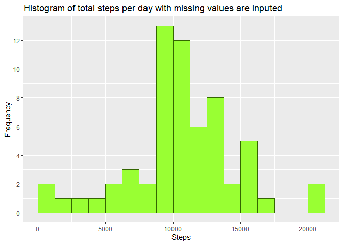

```r
spd2<- aggregate(steps ~ date, alldata, sum)
g<-ggplot(spd2, aes(steps))
g+geom_histogram(boundary=0, binwidth=1250,color="#336600", fill="#99FF33")+
    xlab("Steps")+ ylab("Frequency") +
    ggtitle("Histogram of total steps per day with missing values are inputed")+
    scale_y_continuous(breaks=seq(0,14,2))
```

```r
meanpd2<-mean(spd2$steps, na.rm = TRUE)
medianpd2<-median(spd2$steps, na.rm = TRUE)
```

```r
meanpd2
```

```
## [1] 10574.76
```

```r
medianpd2
```

```
## [1] 10395
```

## 8. Panel plot comparing the average number of steps taken per 5-minute interval across weekdays and weekends

Here I’m presenting two plots of the mean of steps on each interval, one for the weekends and one for the weekdays, using the “alldata2” with inputed values for the NA.

```r
library(ggpubr)

alldata2<-alldata
alldata2$Date <- as.Date(alldata2$date, format = "%Y-%m-%d")
alldata2$wday <- weekdays(alldata2$Date)
alldata2$typday <- ifelse(alldata2$wday=="Samstag" | alldata2$wday=="Sonntag", "weekend","weekday")
head(alldata2)
```

```
##      steps       date interval       Date   wday  typday
## 1 32.31442 2012-10-01        0 2012-10-01 Montag weekday
## 2 32.31442 2012-10-01        5 2012-10-01 Montag weekday
## 3 32.31442 2012-10-01       10 2012-10-01 Montag weekday
## 4 32.31442 2012-10-01       15 2012-10-01 Montag weekday
## 5 32.31442 2012-10-01       20 2012-10-01 Montag weekday
## 6 32.31442 2012-10-01       25 2012-10-01 Montag weekday
```

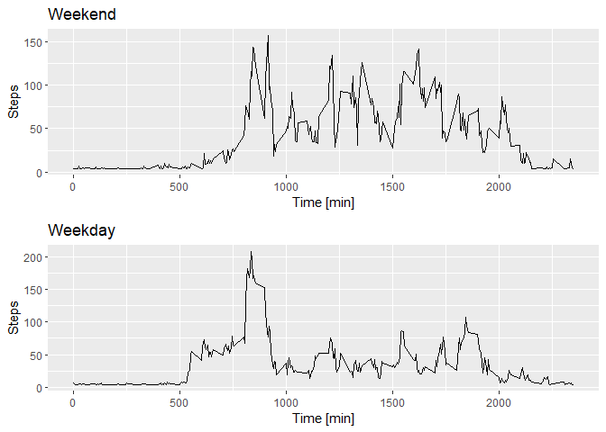

```r
sweekend<-subset(alldata2, typday=="weekend")
sweekday<-subset(alldata2, typday=="weekday")

sendpi<- aggregate(steps ~ interval + typday, sweekend, mean, na.action = na.omit)
j<-ggplot(sendpi, aes(interval, steps), col=typday)
j2<-j+geom_line() + ggtitle("Weekend")+
    xlab("Time [min]")+ ylab("Steps")

sdaypi<- aggregate(steps ~ interval+typday, sweekday, mean, na.action = na.omit)
k<-ggplot(sdaypi, aes(interval, steps))
k2<-k+geom_line() + ggtitle("Weekday")+
    xlab("Time [min]")+ylab("Steps")

figure<-ggarrange(j2, k2, ncol=1, nrow=2)
figure
```